# MEDB 5501, Module03

## Light-tailed distribution, boxplot

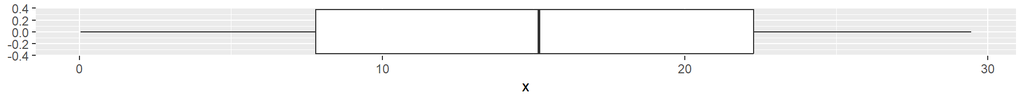

## Light-tailed distribution, qq plot

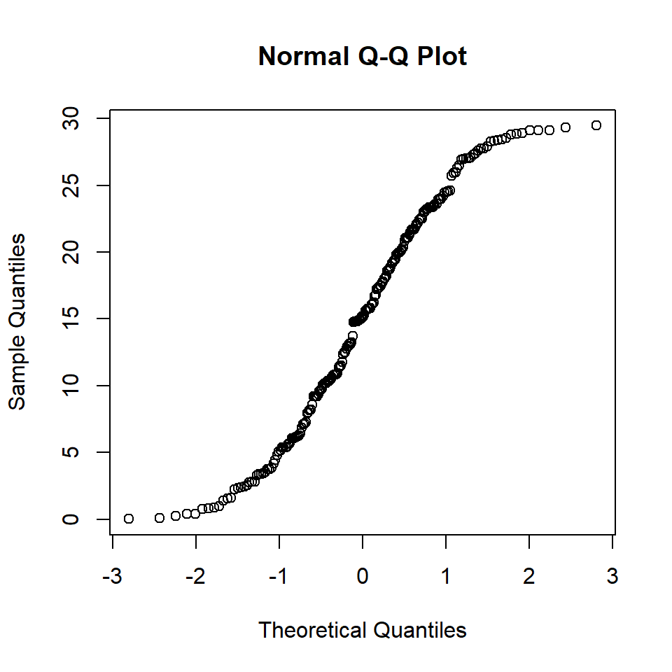

## Heavy-tailed distribution, histogram

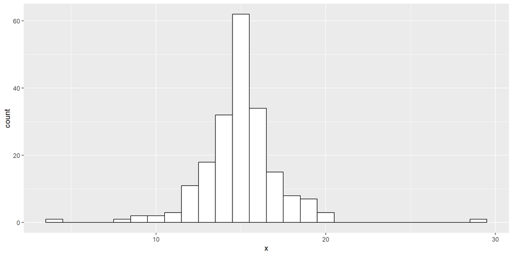

## Heavy-tailed distribution, boxplot

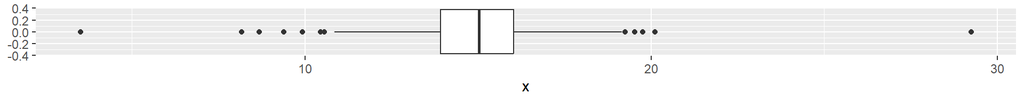

## Heavy tailed data, qq plot

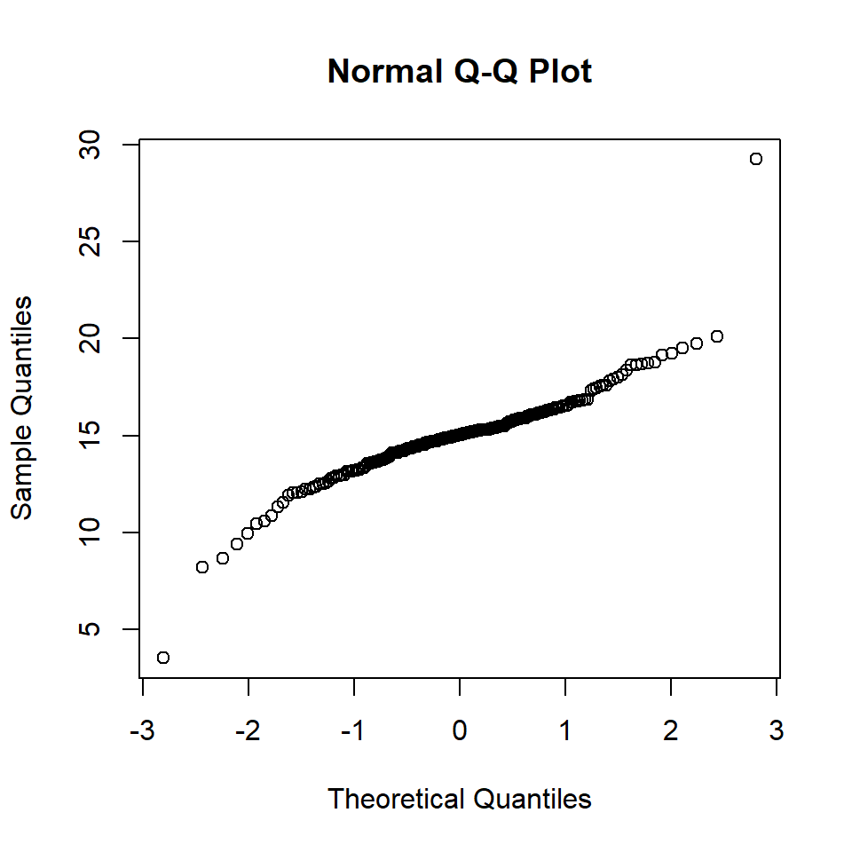

## A normal distribution, histogram

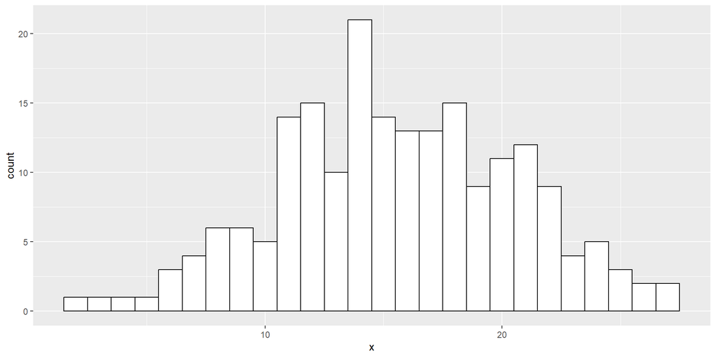

## A normal distribution, boxplot

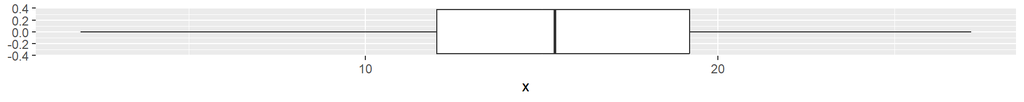

## A normal distribution, qq plot

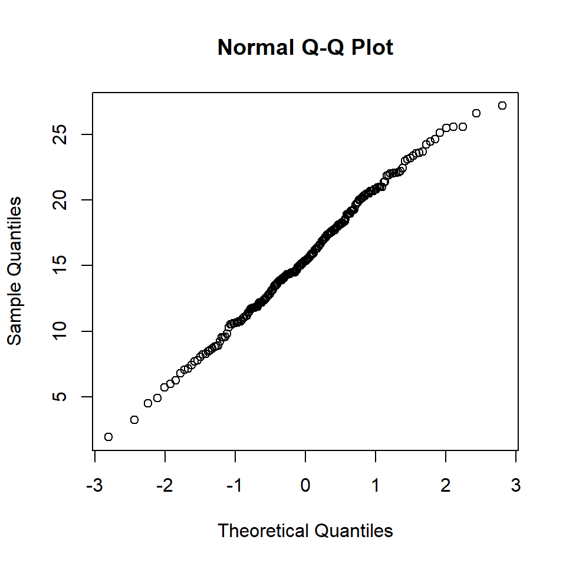

## Break #3

- What you have learned
  - Assessing normality
- What’s coming next
  - Using R to assess normality

## Live demo

Refer to

- The data set, fev.csv
- Its data dictonary, fev.yaml
- The demo program, simon-5501-03-demo.qmd

## Break #4

- What you have learned
  - Using R to assess normality
- What’s coming next
  - Your homework

## Summary

- What you have learned
  - The normal distribution
  - Normal probabilities and quantiles
  - Assessing normality
  - Using R to assess normality
  - Your homework